# Coursework Report

*N* removed NAs: 3

*N* removed typo: 1

[output not shown]

**Main analysis results**

[interactive chart not shown]

[figure not shown]

[interactive chart not shown]

# Coursework Report

Analysing Data, Spring 2020

# Data

## Summary

```
##     id_code           condition   age_years             item_1          item_2          item_3
##  AEKG   :  1   contol      : 1   Length:150         Min.   :2.000   Min.   :2.000   Min.   :2.00
##  AJYG   :  1   control     :72   Class :character   1st Qu.:5.000   1st Qu.:5.000   1st Qu.:5.00
##  APIM   :  1   experimental:77   Mode  :character   Median :6.000   Median :6.000   Median :6.00
##  AVRT   :  1                                        Mean   :6.087   Mean   :5.673   Mean   :5.96
##  AYHB   :  1                                        3rd Qu.:7.000   3rd Qu.:7.000   3rd Qu.:7.00
##  AYLA   :  1                                        Max.   :9.000   Max.   :9.000   Max.   :9.00
##  (Other):144
```

```
## tibble [150 x 6] (S3: tbl_df/tbl/data.frame)
##  $ id_code  : Factor w/ 150 levels "AEKG","AJYG",..: 1 6 81 134 141 96 2 129 18 68 ...
##  $ condition: Factor w/ 3 levels "contol","control",..: 2 2 2 2 2 2 2 2 2 2 ...
##  $ age_years: chr [1:150] "20" "21" "17" "23" ...
##  $ item_1   : num [1:150] 8 6 8 4 6 4 6 7 3 3 ...
##  $ item_2   : num [1:150] 5 6 5 6 3 4 5 4 5 6 ...
##  $ item_3   : num [1:150] 7 7 7 5 4 5 5 3 5 8 ...
```

## Cleaning

```
## .
## 15 16 17 18 19 20 21 22 23 24 26 2e  7
##  1  4  9 18 15 26 36 15 14  6  1  1  1
```

```
## .
## 19 20 21 22 23 24 26
## 15 26 36 15 14  6  1
```

```
## .
##       contol      control experimental
##            1           53           59
```

```
## .
##      control experimental
##           54           59
```

```
##     id_code    condition    age_years         item_1          item_2          item_3
##  AEKG   :  1   white:54   Min.   :19.00   Min.   :3.000   Min.   :2.000   Min.   :2.000
##  AJYG   :  1   red  :59   1st Qu.:20.00   1st Qu.:5.000   1st Qu.:5.000   1st Qu.:5.000
##  APIM   :  1              Median :21.00   Median :6.000   Median :6.000   Median :6.000
##  AVRT   :  1              Mean   :21.09   Mean   :6.088   Mean   :5.673   Mean   :6.062
##  AYHB   :  1              3rd Qu.:22.00   3rd Qu.:7.000   3rd Qu.:7.000   3rd Qu.:7.000
##  AYLA   :  1              Max.   :26.00   Max.   :9.000   Max.   :9.000   Max.   :9.000
##  (Other):107
```

# Tables

Table 1. *Participants’ Ages*

| condition | mean | sd | min | max |
| --- | --- | --- | --- | --- |
| white | 21.02 | 1.52 | 19 | 26 |
| red | 21.15 | 1.39 | 19 | 24 |

Table 2. *Summary of Scores for Question 1*

| condition | mean | sd | min | max |
| --- | --- | --- | --- | --- |
| white | 5.44 | 1.37 | 3 | 9 |
| red | 6.68 | 1.49 | 3 | 9 |

Table 3. *Summary of Scores for Question 2*

| condition | mean | sd | min | max |
| --- | --- | --- | --- | --- |
| white | 5.46 | 1.27 | 3 | 9 |
| red | 5.86 | 1.28 | 2 | 8 |

Table 4. *Summary of Scores for Question 3*

| condition | mean | sd | min | max |
| --- | --- | --- | --- | --- |
| white | 5.39 | 1.58 | 2 | 9 |
| red | 6.68 | 1.20 | 4 | 9 |

Table 5. *Mean Scores for each question*

| condition | item 1 mean | item 2 mean | item 3 mean |
| --- | --- | --- | --- |
| white | 5.44 | 5.46 | 5.39 |
| red | 6.68 | 5.86 | 6.68 |

Table 6. *Mean Attractiveness and SD for all Questions*

|  | Mean | SD |
| --- | --- | --- |
| white | 5.43 | 1.41 |
| red | 6.41 | 1.32 |

# Graphs

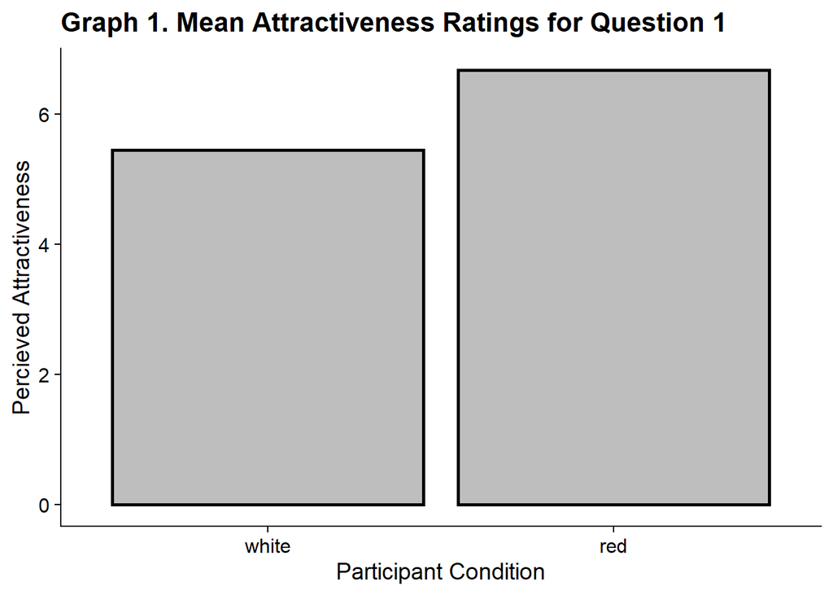

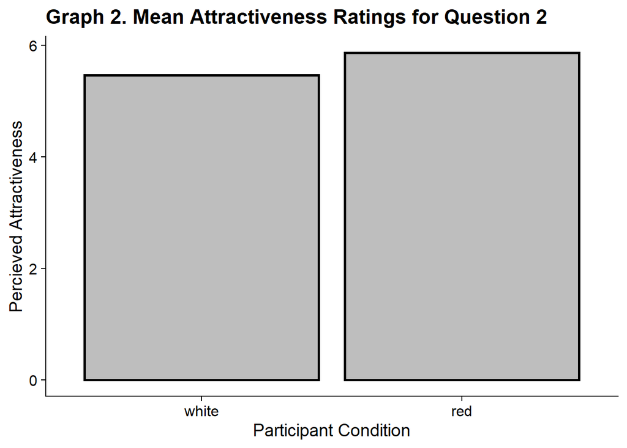

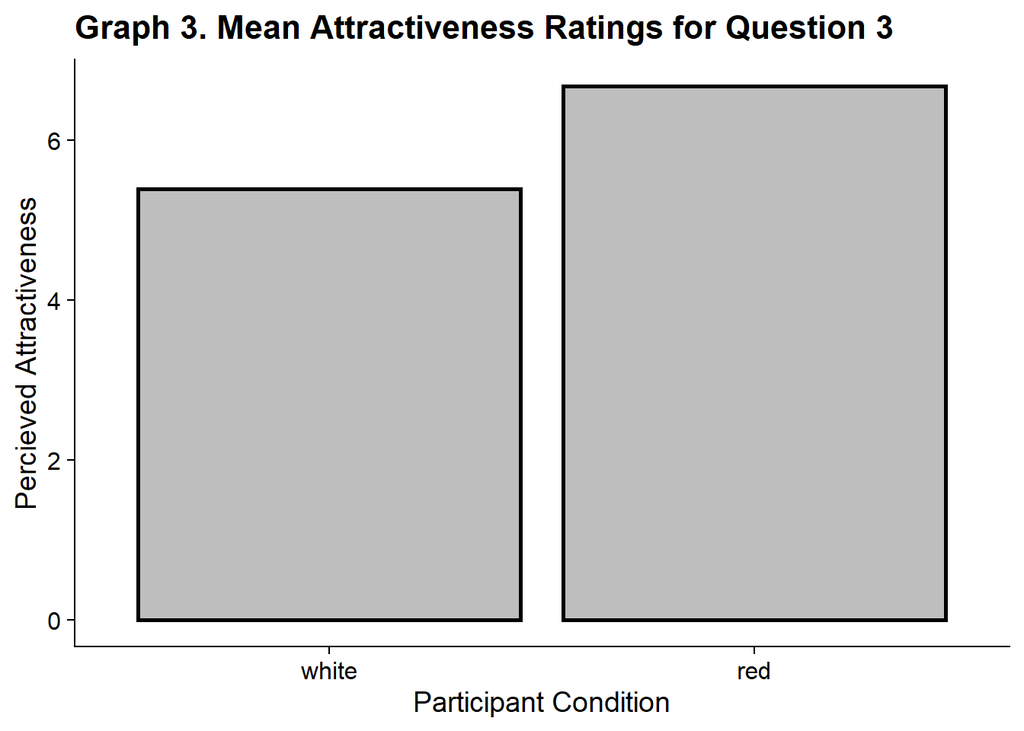

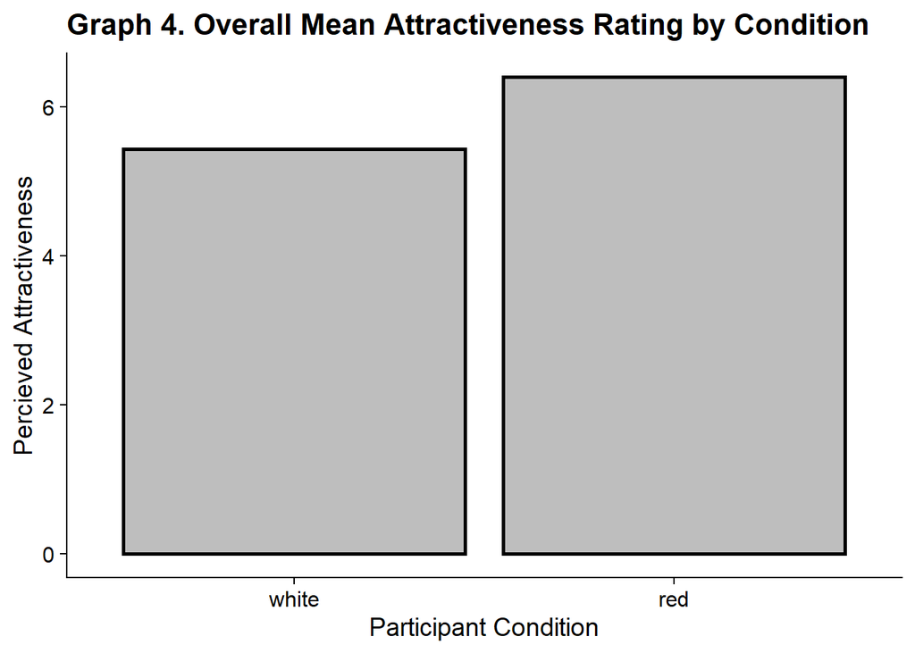

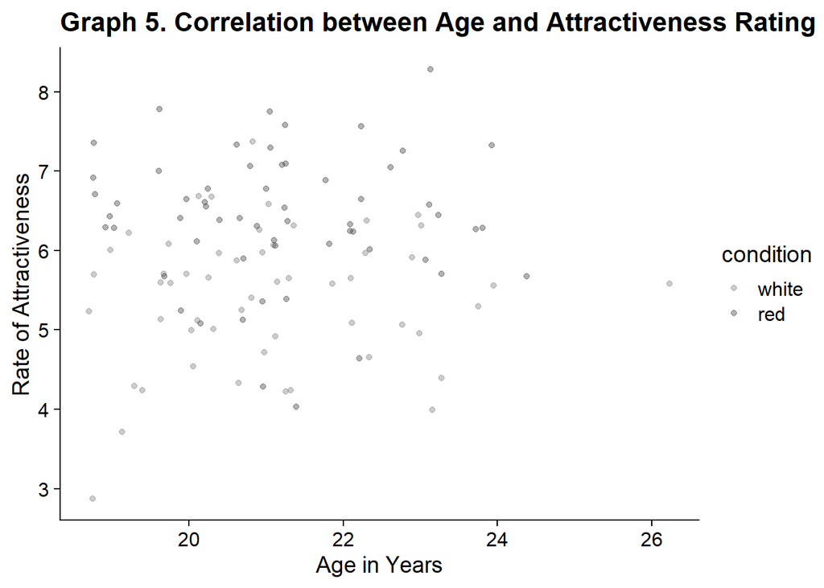

# Statistical Analysis

Table 7. *Correlation Matrix*

|  | item_1 | item_2 | item_3 |
| --- | --- | --- | --- |
| item_1 | 1.0 | 0.10 | 0.30 |
| item_2 | 0.1 | 1.00 | 0.06 |
| item_3 | 0.3 | 0.06 | 1.00 |

Table 8. *Correlation P-values*

|  | item_1 | item_2 | item_3 |
| --- | --- | --- | --- |
| item_1 | NA | 0.273 | 0.001 |
| item_2 | 0.273 | NA | 0.526 |
| item_3 | 0.001 | 0.526 | NA |

```
##
##  Two Sample t-test
##
## data:  (data$item_1 + data$item_2 + data$item_3)/3 by condition
## t = -6.1416, df = 111, p-value = 0.00000001302
## alternative hypothesis: true difference in means is not equal to 0
## 95 percent confidence interval:
##  -1.2891560 -0.6602058
## sample estimates:
## mean in group white   mean in group red
##            5.432099            6.406780
```

# Methods

## Design

In this study we investigated whether association with the colour red would increase perceived attractiveness. To do this we tested the hypothesis: Participants will rate the attractiveness of a man in a photograph higher if it is presented on a red background, than if it is presented on a white background.

This was a between groups design with two conditions; the ‘white condition’ in which 54 participants viewed a black and white photo of a man on white background and the ‘red condition’ in which 59 partcipants viewed the same photo but on a red background for approximately 5 seconds.

Participants then rated the perceived attractiveness of the man in the photograph, assessed by 3 questions: “How attractive do you think this person is?” (item 1 in data), “How pleasant is this person to look at?” (item 2 in data) and “If I were to meet the person in this picture face to face, I would think he is attractive.” (item 3 in data). The items were rated on 9-point scales ranging from 1 (not at all attractive) to 9 (extremely attractive).

We tested the difference in perceived attractiveness by combining the data from each item and using an independent-measures *t*-test to compare the results between conditions. We hypothesised that perceieved attractiveness would be higher from participants in the red condition than the white condition.

# Results

The mean percieved attractiveness rating was higher for the red condition than the white condition for each question (See Tables 2-5 and Graphs 1-3). The difference in means was highest in question 3 with a difference of 1.29 and lowest in question 2 with a difference of 0.4 (See Table 5).

Out of curiosity we investigated whether age had any correlation with perceieved attractiveness - with a particular interest in the red condition. However, there was no apparent correlation between age and attractiveness rating in either the white or red condition (See Graph 5).

To test how similar the different questions were in terms of perceived attractiveness rating we conducted a correlation matrix between items. The correlation of perceived attrativeness ratings between questions was strongest between Question 1 and Question 3 (*r* = 0.3) and weakest between Question 2 and Question 3 (*r* = 0.06) (See Table 7). The *p*-values for the same correlation matrix show that the only significant correlation is between Question 1 and Question 3 (*p* = 0.001) (See Table 8).

# Discussion

This study was a replication of experiment 1 in a paper published in 2010 investigating the same hypothesis. These findings further support the general findings of the original study (Elliot et al., 2010). However, Elliot’s findings were questioned over their significance and it was suggested that he incorrectly rejected the null hypothesis (Francis, 2013). Our replication included a much larger participant sample (113 compared to 21) making these findings more reliable and more generalisable to the population. Both this study and the original support the theory that association with the colour red increases perceived attraction of men.

Elliot also found, both in variations of the original experiments and in a more recent study, evidence to support this theory with the varying gender roles – aka men rating women and men rating men as more attractive when in conjunction with the colour red (Elliot, 2015). This suggests this theory can be applied to all genders and future studies investigating this would be beneficial to this area of research.

However, in another replication of the original study (Hesslinger et al., 2015) found that although the results for experiment one showed a similar pattern when they included more photographs and varied the formality of clothing no significant differences were found between the red and white conditions. This suggests that using more than one photograph of different men and altering different aspects of the pictures may have more to do with the perceived attraction than the background colour. This needs to be investigated further in future studies.

This study included a relatively large sample (113 participants) making the results reliable and generalisable. However, there was no breakdown between gender, sexuality or race meaning individual differences based on these categories cannot be analysed. Furthermore, the use of only one photograph of the same man (whilst reducing the effect of extraneous variables influencing results) mean there is no variation between preference. For example, a participant in the red condition who has a sexual preference for black men may rate perceived attraction as lower due to the fact the man in the photograph was Caucasian. In other words, it allows individual differences and preferences to interfere with the overall pattern of results. In future replications of this study it may be beneficial to include variations of gender (Elliot, 2015, Elliot et al. 2010) and multiple photographs of different subjects (Hesslinger et al. 2015) to achieve a greater overall picture of results.

Perceived attraction was measured using three questions. Higher ratings were found in the red condition for all 3 items, however the difference in means between conditions were higher in question 3. One possibility for this that question 3 allows the participant to consider seeing the man in person, this suggests that participants may be rating attraction as lower because they are only seeing a photograph. An interesting area of research for this topic could be analysing the effect of perceived attraction of men in conjunction in the colour red in person (for example, rating a man wearing a red top vs. the same man wearing a white top).

The smallest difference in means between conditions was found for item 2. When looking at the wording of the question (“How pleasant is this person to look at?”) it is the only question of the 3 that doesn’t include the word ‘attraction’. It’s possible that this influences the participant rating. When using a correlation matrix to analyse the correlation of scores between questions the weakest correlations were between 1 and 2 and 2 and 3. This may also be an effect of the wording of question 2 and this is something for future studies to investigate.

The overall findings of this study displayed significantly higher ratings of perceived attractiveness of a photo of a man on a red background compared to a white background. This supports the theory that perceived attractiveness of human men increases when in conjunction with the colour red. Future replications of this study could include variations of gender, sexuality and race of both the participants and of the subjects they are rating.

# References

Elliot, A.J. (2015) Colour and psychological functioning: a review of theoretical and empirical work. Front. Psychol. 6:368. DOI: 10.3389/fpsyg.2015.00368

Elliot, A. J., Kayser, D. N., Greitemeyer, T., Lichtenfeld, S., Gramzow, R. H., Maier, M. A., & Liu, H. (2010). Red, rank, and romance in women viewing men. Journal of Experimental Psychology: General, 139(3), 399–417. DOI: 10.1037/a0019689

Francis, G. (2013) Journal of Experimental Psychology: General Vol. 142, Iss. 1, 292-296. DOI: 10.1037/a0027923

Hesslinger, V.M., Goldbach, L. & Carbon, C. (2015). Men in red: A re-examination of the red-attractiveness effect. Psychon Bull Rev 22, 1142–1148. DOI: 10.3758/s13423-015-0866-8